# Additional Data

```r
# working directory (should be /final-project-bald_eagle)
knitr::opts_knit$set(root.dir = normalizePath('../'))

# packages
library(tidyverse)
library(janitor)
```

This reads a saved csv of expenditures_ts, written from the code in our_data at commit eaa3885.

```r
# loading data
raw_data <- read_csv('dataset/expenditures_ts.csv',
                     col_types = 'ccccdddddd')
```

For my preference, some cleaning up of names and columns. Adding a binomial (Genus species) column to help with searching later; removing features that aren’t helpful.

```r
# add binomial; remove unnecessary features
expen <- raw_data %>%
  clean_names() %>%
  mutate(binomial = paste(snakecase::to_any_case(genus, 'sentence'),
                          species,
                          sep = ' ')) %>%
  select(class, binomial, fws_total:year)

# should be no NA
any(is.na(expen))
```

```
[1] FALSE
```

Date notes: - There are some errors where species name doesn’t make sense—mis-imported data?

A list of species with most data and most expenditures (both average and overall). `number` is number of data points, `average_exp` is average expenditure, and `overall_exp` is total expenditure for the species.

```r
notable <- expen %>%

  # combine subspecies per year, keep both average and total exp.
  group_by(class, binomial, year) %>%
  summarize(average_subsp = mean(species_total),
            total_subsp = sum(species_total),
            .groups = 'keep') %>%
  ungroup() %>%

  # per-species insights
  group_by(class, binomial) %>%
  summarize(number = n(),
            average_exp = mean(average_subsp),
            average_exp_tot = sum(average_subsp),
            overall_exp_avg = mean(total_subsp),
            overall_exp = sum(total_subsp),
            .groups = 'keep')
```

Species with the most data:

```r
# list
(most_data <- notable %>%
  select(class:number) %>%
  arrange(desc(number)))
```

| class | binomial | number |
| --- | --- | --- |
| actinopteri | Acipenser brevirostrum | 18 |
| actinopteri | Acipenser oxyrinchus | 18 |
| actinopteri | Amblyopsis rosae | 18 |
| actinopteri | Catostomus santaanae | 18 |
| actinopteri | Catostomus warnerensis | 18 |
| actinopteri | Chasmistes brevirostris | 18 |
| actinopteri | Chasmistes cujus | 18 |
| actinopteri | Chasmistes liorus | 18 |
| actinopteri | Crenichthys baileyi | 18 |
| actinopteri | Crenichthys nevadae | 18 |

[output cut: 588 more lines]

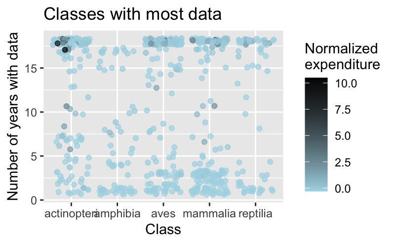

```r
# plot
ggplot(notable, aes(class, number, color = scale(average_exp_tot))) +
  geom_jitter(alpha = 0.7) +
  scale_color_gradient(low = 'lightblue', high = 'black') +
  labs(title = 'Classes with most data',
       x = 'Class',
       y = 'Number of years with data',
       color = 'Normalized\nexpenditure')
```

Species with the most average expenditure:

```r
notable %>%
  select(class, binomial, average_exp) %>%
  arrange(desc(average_exp)) %>%
  head(10) %>%
  .$binomial -> top_avgavg

notable %>%
  select(class, binomial, overall_exp_avg) %>%
  arrange(desc(overall_exp_avg)) %>%
  head(10) %>%
  .$binomial -> top_totavg
```

Species with the most total expenditure

```r
notable %>%
  select(class, binomial, overall_exp) %>%
  arrange(desc(overall_exp)) %>%
  head(10) %>%
  .$binomial -> top_tottot

notable %>%
  select(class, binomial, average_exp_tot) %>%
  arrange(desc(average_exp_tot)) %>%
  head(10) %>%
  .$binomial -> top_avgtot
```

List of all species to pull additional data for. Note that “Ca ca”, “Snake stock”, and “Snake found.” are all non-species.

```r
unique(c(top_avgavg, top_avgtot, top_totavg, top_tottot))
```

```
 [1] "Scaphirhynchus albus"     "Salvelinus confluentus"
 [3] "Oncorhynchus tshawytscha" "Snake stock"
 [5] "Eumetopias jubatus"       "Ca ca"
 [7] "Picoides borealis"        "Oncorhynchus mykiss"
 [9] "Snake found."             "Oncorhynchus nerka"
[11] "Oncorhynchus kisutch"     "Empidonax traillii"
[13] "Xyrauchen texanus"        "Myotis sodalis"
[15] "Oncorhynchus keta"        "Gopherus agassizii"
```

Common names of found species (and file names): pallid sturgeon (Scaphirhynchus albus) -pallid_sturgeon.csv bull trout (Salvelinus confluentus) -bull_trout.csv rainbow trout (Oncorhynchus mykiss) -rainbow_trout.csv

(salmon are mostly together) Chinook salmon (Oncorhynchus tshawytsch) sockeye salmon (Oncorhynchus nerka) coho salmon (Oncorhynchus kisutch) chum salmon (Oncorhynchus keta) -salmon.pdf (different data than salmon.csv; needs scraping) -salmon.csv -chinook.pdf -survival_chinook_steelhead.csv

Datasets not found/not looked for: Steller sea lion red-cockaded woodpecker willow flycatcher razorback sucker Indiana bat desert tortoise

For some preliminary analysis, a look into the pallid sturgeon. Note that the survey data was from various surveys, so it was averaged per year (to avoid overweighting a year with more surveys).

```r
raw_sturgeon <- read_csv('dataset/additional/pallid_sturgeon.csv',
                         col_types = 'ciccdddd')

# years surveyed per waterbody
raw_sturgeon %>%
  clean_names() %>%
  select(year, waterbody, count) %>%
  group_by(waterbody) %>%
  summarize(num_years = length(unique(year)),
            .groups = 'keep')
```

| waterbody | num_years |
| --- | --- |
| Fort Peck Dredge Cuts | 1 |
| Fort Peck Lake | 12 |
| Milk River | 1 |
| Missouri River | 9 |
| Yellowstone River | 10 |

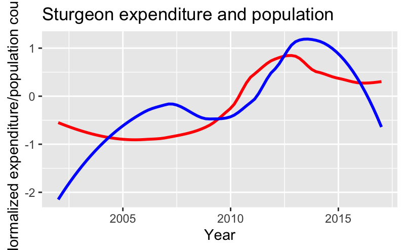

```r
# mean counts after outliers removed
sturgeon <- raw_sturgeon %>%
  clean_names() %>%
  filter(!waterbody %in% c('Fort Peck Dredge Cuts', 'Milk River')) %>%
  select(year, count) %>%
  group_by(year) %>%
  summarize(avg_count = mean(count),
            .groups = 'keep') %>%
  arrange(year)

# sturgeon expenditure
sturgeon_exp <- expen %>%
  filter(binomial == 'Scaphirhynchus albus') %>%
  inner_join(sturgeon, by = 'year')

# plot expenditure vs sturgeon
ggplot(sturgeon_exp, aes(year)) +
  geom_smooth(aes(y = scale(avg_count)),
              color = 'red',
              se = F) +
  geom_smooth(aes(y = scale(species_total)),
              color = 'blue',
              se = F) +
  labs(title = 'Sturgeon expenditure and population',
       x = 'Year',
       y = 'Normalized expenditure/population counts')
```

```r
# linear model
reg_sturgeon <- lm(avg_count ~ species_total,
                   data = sturgeon_exp)
summary(reg_sturgeon)
```

```
Call:
lm(formula = avg_count ~ species_total, data = sturgeon_exp)

Residuals:
   Min     1Q Median     3Q    Max
-6.569 -5.080 -2.606  1.897 15.078

Coefficients:
               Estimate Std. Error t value Pr(>|t|)
(Intercept)   5.534e-01  6.208e+00   0.089    0.931
species_total 1.369e-07  1.374e-07   0.996    0.343

Residual standard error: 7.411 on 10 degrees of freedom
Multiple R-squared:  0.09025,   Adjusted R-squared:  -0.000725
F-statistic: 0.992 on 1 and 10 DF,  p-value: 0.3427
```

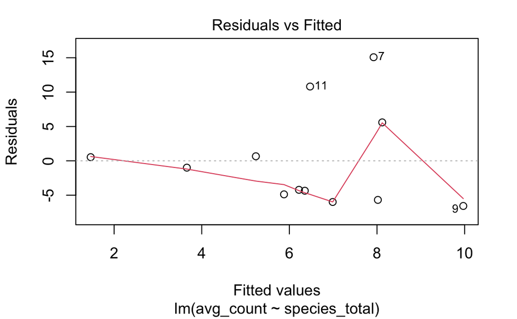

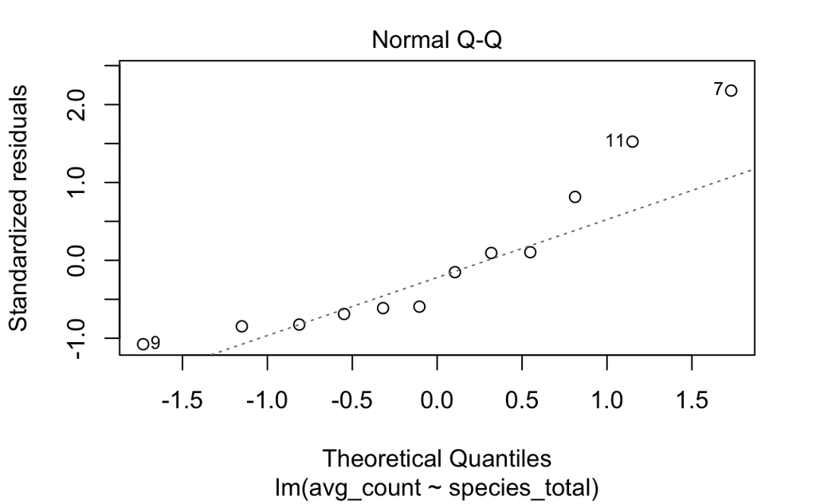

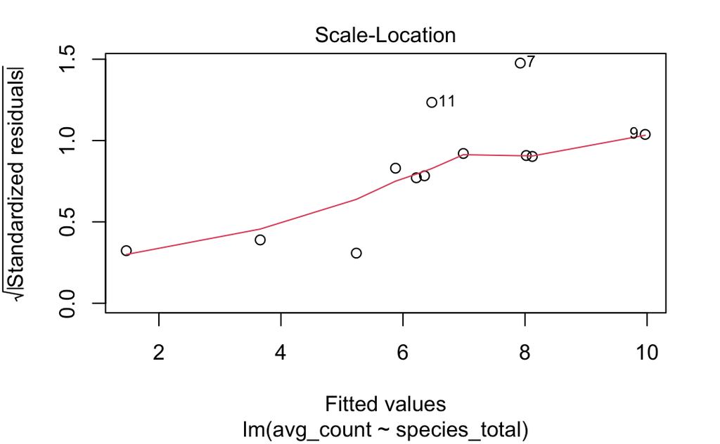

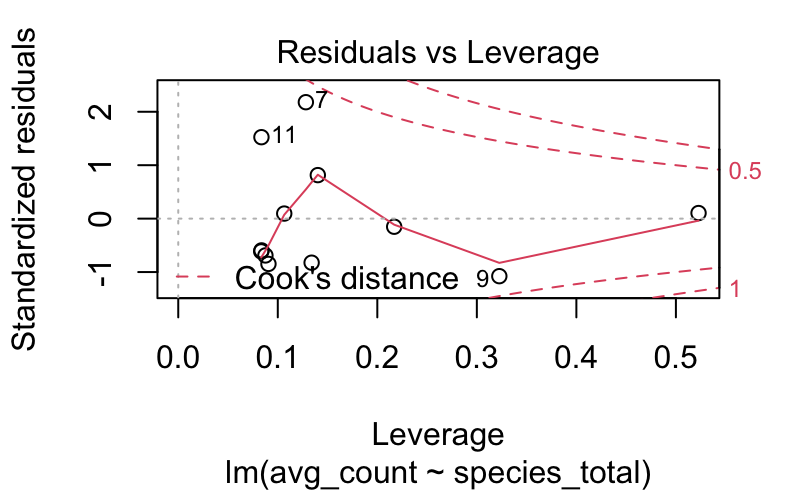

```r
plot(reg_sturgeon)
```

```r
# pretty badly not normal, maybe log or polynomial?
reg_sturgeon2 <- lm(log(avg_count) ~ species_total,
                   data = sturgeon_exp)
summary(reg_sturgeon2)
```

```
Call:
lm(formula = log(avg_count) ~ species_total, data = sturgeon_exp)

Residuals:
    Min      1Q  Median      3Q     Max
-1.3797 -0.6176 -0.2533  0.7489  1.6268

Coefficients:
               Estimate Std. Error t value Pr(>|t|)
(Intercept)   4.901e-01  8.980e-01   0.546    0.597
species_total 1.892e-08  1.988e-08   0.952    0.364

Residual standard error: 1.072 on 10 degrees of freedom
Multiple R-squared:  0.08307,   Adjusted R-squared:  -0.00862
F-statistic: 0.906 on 1 and 10 DF,  p-value: 0.3636
```

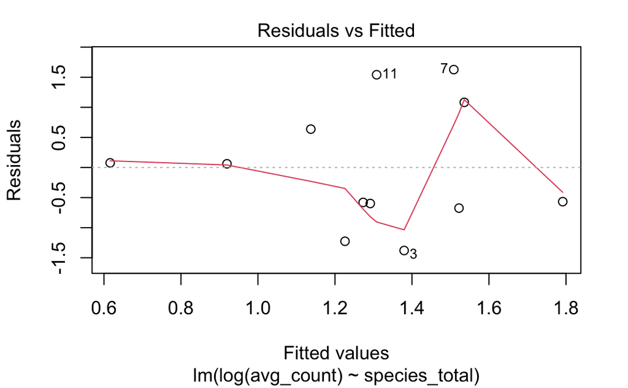

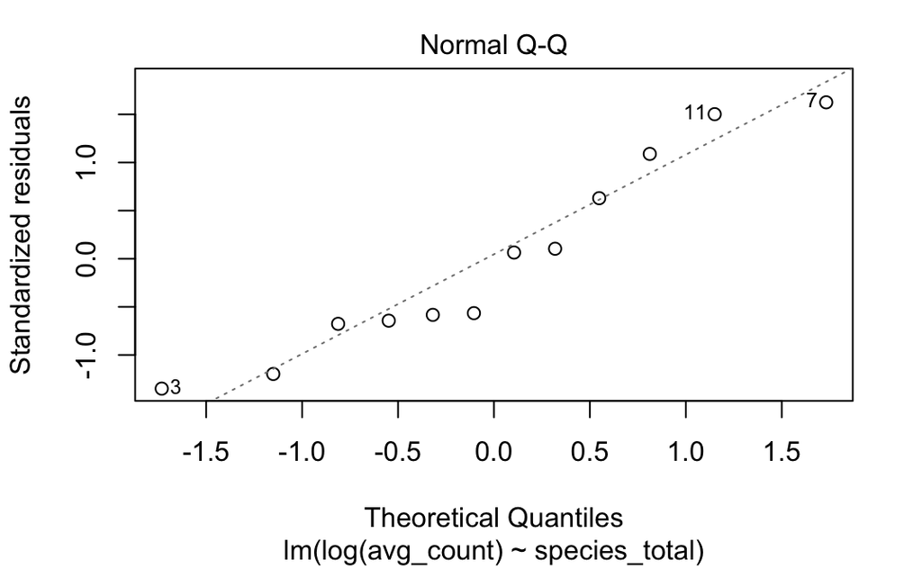

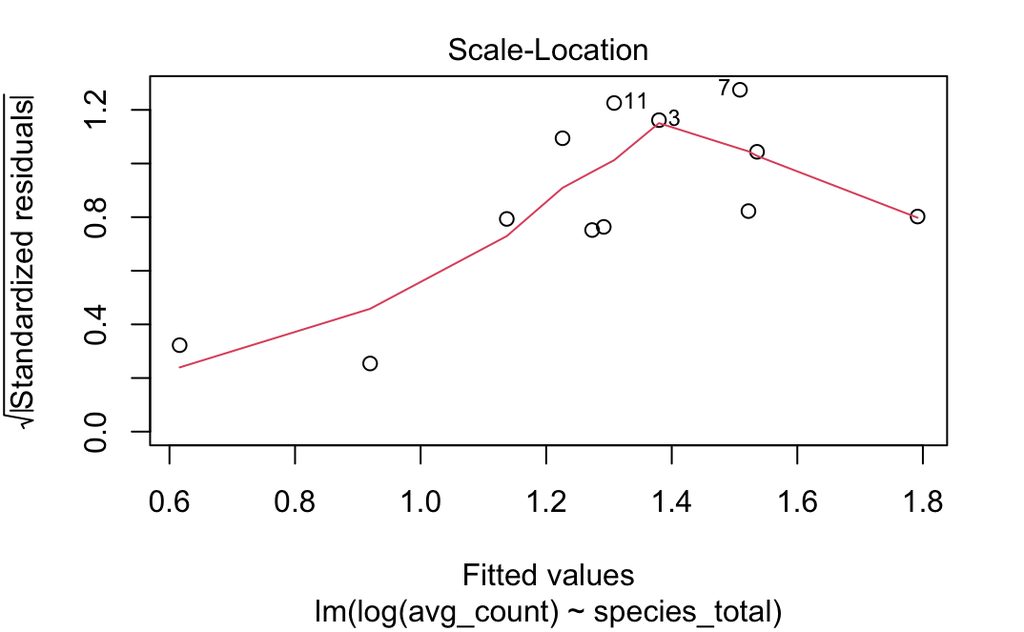

```r
plot(reg_sturgeon2)
```

[figure not shown]

```r
NA
```

[output not shown]

[figure not shown]

```r
ggplot(sturgeon_exp, aes(year)) +
  geom_smooth(aes(y = avg_count,
                  color = 'red'),
              se = F) +
  geom_smooth(aes(y = species_total/10000000,
                  color = 'blue'),
              se = F) +
  scale_x_discrete(limits = seq(2002,2016,2)) +
  scale_color_discrete(name = "Key",
                       labels = c("Count", "Expenditure\n($10,000,000s)")) +
  labs(title = 'Sturgeon expenditure and population counts',
       x = 'Year',
       y = 'Expenditure and average counts')
```